# slide_deck_template slides

## Prosperating & Credit Grade overview

Prosper rating grade was plotted to see if there is a difference between regular credit grade system. Prosper loan company rated borrowers without credit information on their data. Prosper rating have a higher count since prosper have fewer null values; their highest count is also graded C. Prosper rating seems to have similar grading quota as a regular credit grading system.

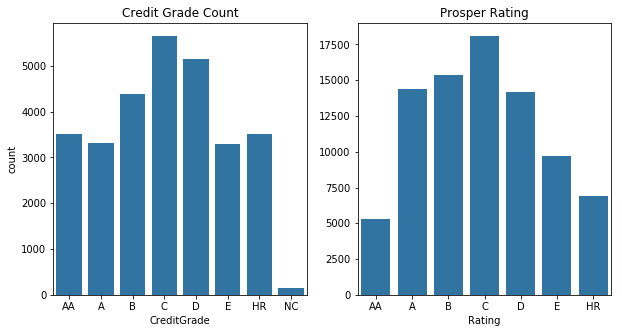

```python
plt.figure(figsize=[10,5])

plt.subplot(1,2,1)
sb.countplot(data = df_clean, x = 'CreditGrade', order =['AA', 'A', 'B', 'C', 'D', 'E', 'HR', 'NC'], color = base_color)
plt.title('Credit Grade Count')
# There is not enough information about credit grade Assume same as prosper rating system
# 0 - NC, 1 - HR, 2 - E, 3 - D, 4 - C, 5 - B, 6 - A, 7 - AA

plt.subplot(1,2,2)
sb.countplot(data = df_clean, x = 'ProsperRating(alpha)', order = ['AA','A','B','C','D','E','HR'], color= base_color)
plt.title('Prosper Rating')
plt.xlabel('Rating')
plt.ylabel('');
```

## Borrower State Count

Borrower State count-plot were plotted to see where borrowers are from. California had the highest count of 51 states recording 13.57% of all borrowers; the second was Texas with 6.31% proportion. Adding top 10 states proportion, the ten total proportion was around 55%.

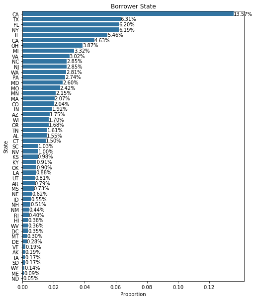

```python
plt.figure(figsize=(8,10))
sb.countplot(data = df_clean, y = 'BorrowerState',
            order = state_order, color = base_color)
plt.xticks(tick_prop * n_state, tick_name)
plt.ylabel('State')
plt.xlabel('Proportion')
plt.title('Borrower State')

for i in range(state_order.shape[0]):
    count = state_counts[i]
    pct_string = '{:0.2f}%'.format(100*count/n_state)
    plt.text(count + 1, i, pct_string, va = 'center')
```

## Occupation Count

Occupation count-plot was plotted to see which occupation is the borrower of prosper loan. The highest proportion of occupation was “Other” which indicates that it is not in the prosper loan occupation category. Top 5 occupation on the dataset is almost 50% of the borrowers.

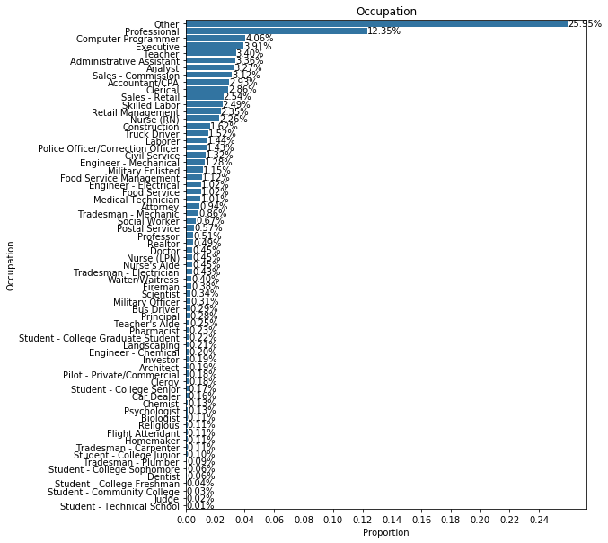

```python
plt.figure(figsize=(8,10))
sb.countplot(data = df_clean, y = 'Occupation',
            order = Occupation_order, color = base_color)
plt.xticks(tick_prop * n_Occu, tick_name)
plt.ylabel('Occupation')
plt.xlabel('Proportion')
plt.title('Occupation')

for i in range(Occupation_order.shape[0]):
    count = Occu_counts[i]
    pct_string = '{:0.2f}%'.format(100*count/n_Occu)
    plt.text(count + 1, i, pct_string, va = 'center')
```

## Credit Score & Borrower APR Relationship

Credit Score and Borrower APR data were plotted on scatter plot to see the relationship. X-axes limit was held from 300 to 900 to eliminate outliers on 0 credit scores. When plotted without alpha rate, the plot points were spread out wide alpha rate 1/20 was held to see where plots are more likely to distributed. APR and Credit score have a negative relationship, as a credit score increase, APR decrease.

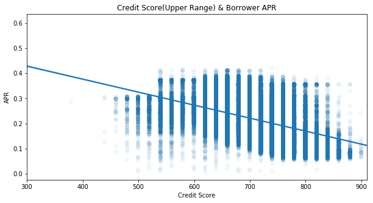

```python
plt.figure(figsize=(10,5))

sb.regplot(data = df_numical, x = 'CreditScoreRangeUpper', y = 'BorrowerAPR', x_jitter= 0.3,
          scatter_kws = {'alpha' : 1/20})
plt.title('Credit Score(Upper Range) & Borrower APR')
plt.xlabel('Credit Score')
plt.ylabel('APR')

plt.xlim(300,910);
```

## Estimated Return & Estimated Loss Relationship

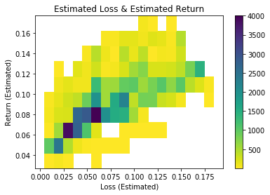

```python
bins_x = np.arange(loan_unclosed['EstimatedLoss'].min()- 0.01, 0.2, 0.01)
bins_y = np.arange(loan_unclosed['EstimatedReturn'].min() - 0.01, 0.180, 0.015)

plt.hist2d(data = loan_unclosed, x = 'EstimatedLoss', y = 'EstimatedReturn', cmin = 1,
          cmap = 'viridis_r', bins = [bins_x, bins_y])
plt.colorbar()
plt.title('Estimated Loss & Estimated Return')
plt.xlabel('Loss (Estimated)')
plt.ylabel('Return (Estimated)');
```

## Borrower APR by Credit Grade

Credit Grade and Borrower APR variables were plotted on a box plot. As credit grade decreased borrower APR increased. The plot indicates that NC(no credit) has a lower APR than grade ‘E’ and ‘HR.’

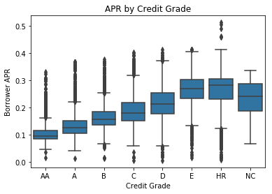

```python
sb.boxplot(data = df_clean, x = 'CreditGrade', y = 'BorrowerAPR',
           order = grade_order, color = base_color)
plt.title('APR by Credit Grade')
plt.xlabel('Credit Grade')
plt.ylabel('Borrower APR');
```

## Top 5 Occupation & APR

Top 5 count occupation and Borrower APR were plotted on a box plot. According to the graph, Executive occupation had the highest minimum APR, and computer programmer is the second. However, the computer programmer had the lowest median APR.

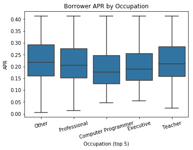

```python
sb.boxplot(data= df_clean, x = 'Occupation', y = 'BorrowerAPR', order = top_5, color = base_color)
plt.xticks(rotation = 15)
plt.title('Borrower APR by Occupation')
plt.ylabel('APR')
plt.xlabel('Occupation (top 5)')
```

## Top 10 State & APR

Top 10 count state and Borrower APR were plotted on the box plot. The states seem to have similar median APR, but Florida, Georgia, Ohio, and Virginia’s minimum APR were higher than the other six states

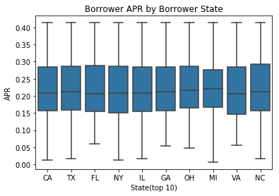

```python
top_10 =df_clean['BorrowerState'].value_counts().head(10).index
sb.boxplot(data= df_clean, x = 'BorrowerState', y = 'BorrowerAPR', order = top_10, color = base_color)
plt.title('Borrower APR by Borrower State')
plt.ylabel('APR')
plt.xlabel('State(top 10)')
```

## Data Problem?

Income data were plotted with Listing creation date data. Even though the graph is not accurate; the graph shows data input gap between from 2009 May to 2009 July. There must be a data management problem or company problem between the time.

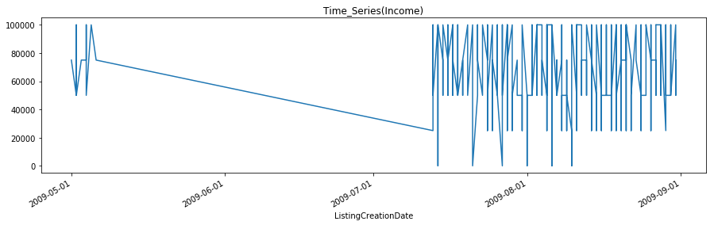

```python
plt.figure(figsize=(15,4))
ax = prosper_date.loc['2009-05':'2009-08', 'IncomeRange(high)'].plot()
plt.title('Time_Series(Income)');
plt.xticks(['2009-05-01','2009-06-01','2009-07-01','2009-08-01','2009-09-01']);
```

## Credit Score & APR by Year

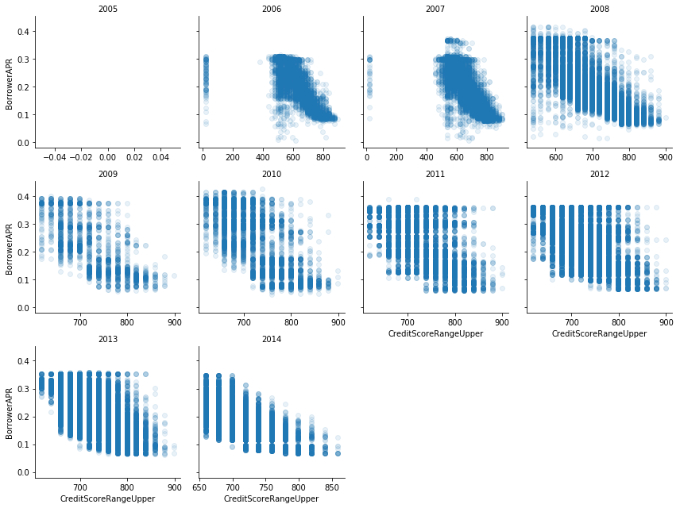

```python
g = sb.FacetGrid(data = df_clean, col = 'LoanOrigination(Year)', col_wrap=4, sharex=False)
g.map(plt.scatter, 'CreditScoreRangeUpper','BorrowerAPR', alpha = 1/10);
g.set_titles('{col_name}');
```

## Estimated Loss and Return by Prosper Rating

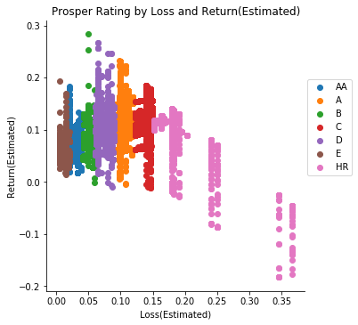

```python
g = sb.FacetGrid(data = df_clean, hue = 'ProsperRating(alpha)', height = 5)
g.map(plt.scatter, 'EstimatedLoss','EstimatedReturn')
plt.legend(['AA','A','B','C','D','E','HR'], bbox_to_anchor=(1.2,0.8))
plt.title('Prosper Rating by Loss and Return(Estimated)');
plt.xlabel('Loss(Estimated)')
plt.ylabel('Return(Estimated)');
```